# Wilcoxon Rank-Sum Test for ANES data

## Imports

The library effsize is not installed by default, you might need to install it using `install.packages(effsize)`

```r
library(dplyr)
library(readr)
library(tidyverse)
library(ggplot2)
require(effsize)
library(effsize)
```

## Load data

```r
anes <- read_csv("./data/anes_timeseries_2020_csv_20220210.csv")
```

## Rename variables

```r
# Keep only variables of interest
keeps = c(
  "V201600",   # gender
  "V201507x",  # age
  "V201511x",  # education
  "V201549x",  # race
  "V201567",   # children
  "V201617x",  # family income
  "V202109x",  # turnout in 2020 election
  "V202110x",  # 2020 presi vote
  "V202111x",  # 2020 house vote
  "V202112x",  # 2020 senate vote
  "V202113x",  # 2020 gov vote
  "V201231x",  # party ID
  "V201019",   # pre. intend to register to vote
  "V202051",   # post. registered to vote
  "V202117",   # voting method
  "V202118",   # usual voting method
  "V202119",   # how difficult to vote
  "V202120a",  # registration issues?
  "V202120b",  # concern on ID card?
  "V202120c",  # diffculties with absentee ballot
  "V202120d",  # confusion on ballot/machine
  "V202120e",  # difficulty getting to polling place
  "V202120f",  # long wait time at polling place
  "V202120g",  # work schedule
  "V202120h",  # bad weather
  "V202120i",  # issue mailing ballot
  "V202120j",  # other issue
  "V202120k",  # no issues voting
  "V202121",   # how long the wait
  "V202122",   # how long to get to polling line
  "V202123",   # main reason not to vote
  "V202124"    # other reason not to vote
)

column_names = c(
  "gender",
  "age",
  "education",
  "race",
  "children",
  "income",
  "voted_2020",
  "v2020_presi",
  "v2020_house",
  "v2020_senate",
  "v2020_gov",
  "party",
  "pre_intent_to_vote",
  "post_registered_to_tove",
  "voting_method",
  "usual_voting_method",
  "diffvote",
  "diffvote_reg",
  "diffvote_idcard",
  "diffvote_aballot",
  "diffvote_confmach",
  "diffvote_gopolling",
  "diffvote_wait",
  "diffvote_work",
  "diffvote_weather",
  "diffvote_mail",
  "diffvote_other",
  "diffvote_none",
  "diffvote_wait_time",
  "diffvote_gopolling_time",
  "diffvote_mainreason",
  "diffvote_otherreason"
)

anes_filt = anes[keeps]
colnames(anes_filt) = column_names
```

## Define party

If user is any level of democrat (1, 2, 3), the set as “Democrat”, if user is any level of Republican (5, 6, 7), then set as “Republican”. If user is independent (4), then set as “Independent”:

```r
# Create party column
anes_filt = anes_filt %>%
  mutate(party_self = case_when(
    party %in% c(1, 2, 3) ~ "Democrat",
    party %in% c(5, 6, 7) ~ "Republican",
    party %in% c(4)       ~ "Independent"
  ))
```

The `%>%` and `mutate` operators are part of `dplyr` package. The `%>%` works as the `.` operator in Python, it allow us to chain methods. Mutate allow us to create a new column using a multiple conditional statement.

## Clean Data

We are only going to use those who voted in 2020. Create a new dataset with voters only:

```r
anes_voted = anes_filt %>% filter(voted_2020 == 1)
```

We also want to filter out independents as well as those that don’t have a value for voting difficulty (either negative or NA value):

```r
anes_voted_party_clean = anes_voted %>%
  filter(
    # Filter out NAs or negative values in difficulty voting
    diffvote >= 0 & !is.na(diffvote) &
    # Keep only reps and demos
    party_self %in% c("Republican", "Democrat"))
```

#### Plot distributions

Remember, 1=No difficulty voting and 5=Extremely diffcult to vote.

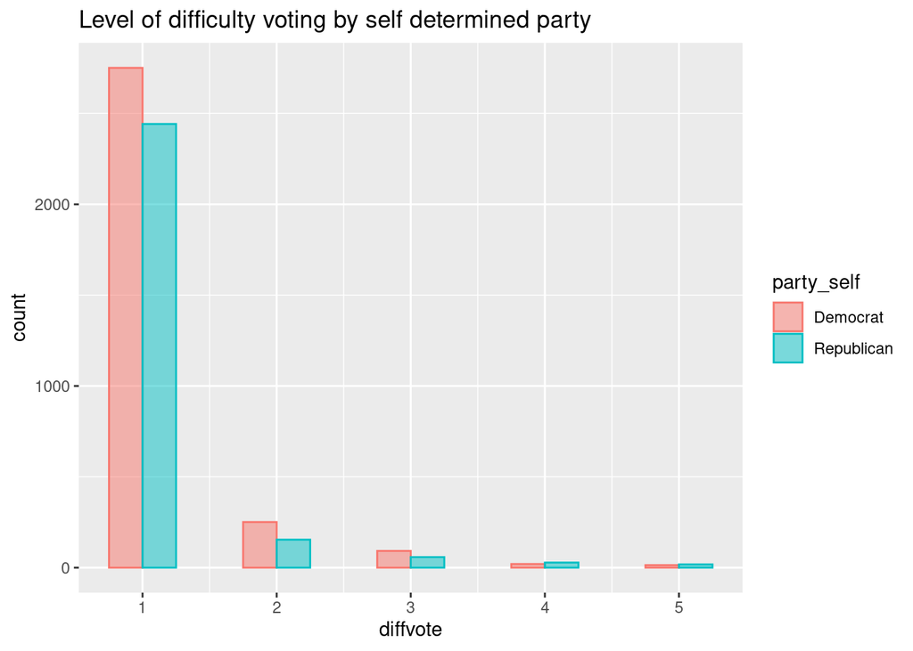

```r
anes_voted_party_clean %>%
  ggplot() +
  aes(x=diffvote, fill=party_self, color=party_self) +
  geom_bar(alpha=0.5, position="dodge", width=0.5) +
  labs(title="Level of difficulty voting by self determined party")
```

## Test

Now we can run the test (double tailed). We will assume that $\alpha=0.05$.

$H_0$: Probability of drawing a higher rank (i.e. difficulty) for Democrat is the same as the probability of drawing a higher rand if Republican $\rightarrow P(X<Y) = P(Y<X)$

$H_a$: Probability of drawing a higher rank (i.e. difficulty) for Democrat is NOT the same as the probability of drawing a higher rand if Republican $\rightarrow P(X<Y) \neq P(Y<X)$

```r
wt = wilcox.test(diffvote ~ party_self, data = anes_voted_party_clean,
            alternative="two.sided",
            conf.int = TRUE,
            conf.level=0.95)
wt
```

[output not shown]

The p-value is less than 0.05, so at $\alpha=0.05$, we reject $H_0$.

### Practical Significance

Although the test is *statistically* significant, it is not *practically* significant. The difference between distributions is very small.

Because the metric of the test is *not* very intuitive, we calculate 3 different metrics to interpret the effect size.

1. By default, R calculates the Hodges-Lehman estimator of effect size which is very small:

```r
wt$estimate
```

```
## difference in location
##           3.188358e-05
```

2. The async suggested that the best effect size for this is the correlation effect size $r=\frac{Z}{\sqrt{N}}$. Which is also very small:

```r
z = qnorm(wt$p.value)
N = count(anes_voted_party_clean)
eff_corr = z/sqrt(N)

as.numeric(eff_corr)
```

```
## [1] -0.03527551
```

3. We can also calculate Cohen’s D metric (this requires the `effsize` package). This specifies how many standard deviations away from the population is one distribution from another one. Again, very small:

```r
cohen.d(diffvote ~ party_self, data = anes_voted_party_clean)
```

```
##
## Cohen's d
##
## d estimate: 0.03319572 (negligible)
## 95 percent confidence interval:
##       lower       upper
## -0.01830491  0.08469636
```